# IDW model for short-term and long-term sensors

Jordan Wingenroth

May 31, 2018

```r
library(tidyverse)
library(readxl)
library(lubridate)
library(maps)
library(gstat)
library(animation)
library(gganimate)
library(sp)
library(knitr)
```

# geographic data setup

It seemed to make the most sense to load the pm 2.5 data from longterm sensors at the same time since the lat/long was included in the same table. The pm 2.5 dataset was a large file (10 MB) since it included all October data for the entire state, so I filtered it to only include sites within ~1 deg of the centerpoint of sampling sites in Excel prior to adding to the project.

```r
st_sensors <- read_csv(file = "../data/aq_sensors.csv")
st_sensors <- filter(st_sensors, `sensor class` == "short_term")

long_term_pm25 <- read_csv("../data/long_term_pm25.csv")
lt_sensors <-long_term_pm25 %>%
  distinct(name, .keep_all = TRUE) %>%
  transmute(name, "sensor class" = "long_term", latitude, longitude)

farms <- read_csv(file = "../data/farm_data.csv")
hysplit <- readxl::read_xlsx(path = "../data/HYSPLIT_data.xlsx")

all(sort(hysplit$Address)==sort(farms$address))
```

```
## [1] TRUE
```

```r
#farm

farms <- left_join(farms, hysplit, by = c("address" = "Address"))

farms <- farms %>%
  dplyr::select(address, Key, long, lat, `Exposure (raw, final model, normalized)`, `Exposure (smoothed, final model, normalized)`, `Rank (raw)`, `Rank (smoothed)`)

rm(list = "hysplit")

#aq_sensors

aq_sensors <- rbind(lt_sensors, st_sensors)
rm(list = c("lt_sensors", "st_sensors"))
aq_sensors <- rename(aq_sensors, lat = latitude, long = longitude)
```

# map with farm sites and aq sensors

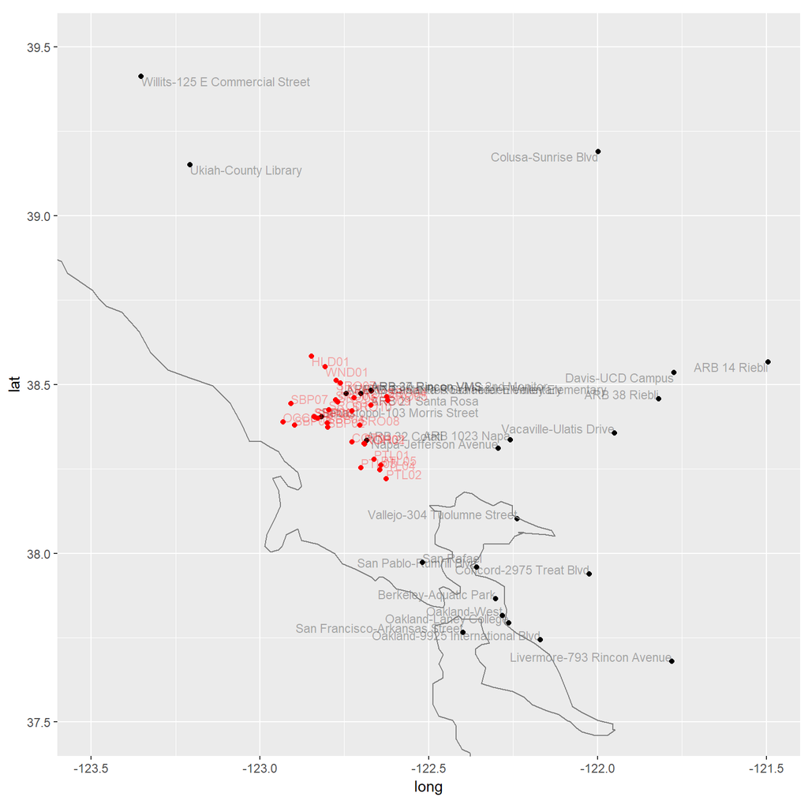

```r
ggplot(NULL, aes(long, lat)) +
  geom_point(data = aq_sensors) +
  geom_text(data = aq_sensors, color = "black", alpha = .3, aes(label = name), hjust = "inward", vjust = "inward", size = 3) +
  geom_point(data = farms, color = "red") +
  geom_text(data = farms, color = "red", alpha = .3, aes(label = Key), hjust = "inward", vjust = "inward", size = 3) +
  borders("state", "California") +
  coord_fixed(xlim = c(-123.5,-121.5), ylim = c(37.5, 39.5))
```

We’re lacking sensors to the northwest of the sites, but we have a good number to the southeast (Vacaville, Vallejo, Berkeley, SF, Oakland).

ARB 14 & 38 Riebli sites have incorrect GPS data???

# fix Riebli data

```r
#values from Google Maps
aq_sensors[grep("Riebli", aq_sensors$name),]$lat <- 38.500
aq_sensors[grep("Riebli", aq_sensors$name),]$long <- -122.741
```

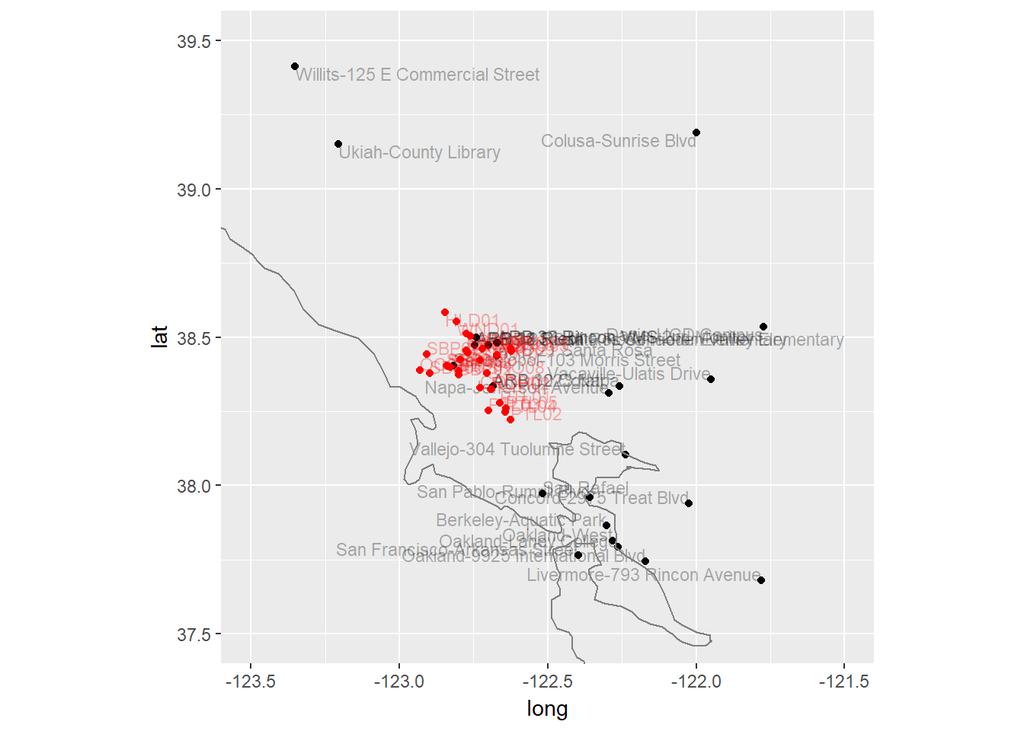

```r
ggplot(NULL, aes(long, lat)) +
  geom_point(data = aq_sensors) +
  geom_text(data = aq_sensors, color = "black", alpha = .3, aes(label = name), hjust = "inward", vjust = "inward", size = 3) +
  geom_point(data = farms, color = "red") +
  geom_text(data = farms, color = "red", alpha = .3, aes(label = Key), hjust = "inward", vjust = "inward", size = 3) +
  borders("state", "California") +
  coord_fixed(xlim = c(-123.5,-121.5), ylim = c(37.5, 39.5))
```

# PM 2.5 data setup

```r
st_files <- list.files("../data/short_term_pm25", full.names = TRUE)
short_term_pm25 <- lapply(st_files, function(x) read_xlsx(x))
names(short_term_pm25) <- str_sub(st_files, 42, -20)
for (i in 1:length(short_term_pm25)) short_term_pm25[[i]] <- mutate(short_term_pm25[[i]], name = names(short_term_pm25[i]))
short_term_pm25 <- do.call(rbind, short_term_pm25)
short_term_pm25 <- dplyr::select(short_term_pm25, name, everything())

sort(unique(short_term_pm25$name))==sort(aq_sensors[aq_sensors$`sensor class`=="short_term",]$name)
```

```
## [1]  TRUE  TRUE FALSE  TRUE  TRUE  TRUE FALSE  TRUE FALSE
```

Some of the short term sensors have different, but easily matchable names.

```r
#short-term times

short_term_pm25 <- short_term_pm25 %>%
  mutate(datetime = `Date/Time/` + 3600*hour(PST))


#long-term times

long_term_pm25 <- long_term_pm25 %>%
  mutate(date = as.POSIXct(long_term_pm25$date, format = "%m/%d/%Y"), datetime = date + 3600*start_hour)

#match sites to aq sensors by key

aq_sensors$key <- str_sub(aq_sensors$name, end = 10)
long_term_pm25$key <- str_sub(long_term_pm25$name, end = 10)
short_term_pm25$key <- str_sub(short_term_pm25$name, end = 10)

sum(sort(unique(aq_sensors$key))==sort(c(unique(long_term_pm25$key), unique(short_term_pm25$key))))
```

```
## [1] 26
```

```r
#pull out and match up essential columns for purpose of rowbinding and joining

t1<-short_term_pm25 %>%
  dplyr::select(key, name, datetime, value = ConcHr)

t2<-long_term_pm25 %>%
  dplyr::select(key, name, datetime, value)

#rowbind and join to gps data

pm25 <- rbind(t1, t2)

pm25 <- pm25 %>%
  left_join(aq_sensors, "key") %>%
  dplyr::select(-name.y) %>%
  rename(name = name.x)

rm(list = c("aq_sensors","long_term_pm25","short_term_pm25","t1","t2"))

#Filter out negative values and zero values as they could be errors and should be bounded by small nummbers (safe)
#Also filter out some Vacaville values that appear to be errors (>900 ug/m3)

pm25 <- pm25 %>%
  filter(value>=0, value<900)
```

# convert lat/long to kilometers for all data

Data from http://www.csgnetwork.com/degreelenllavcalc.html

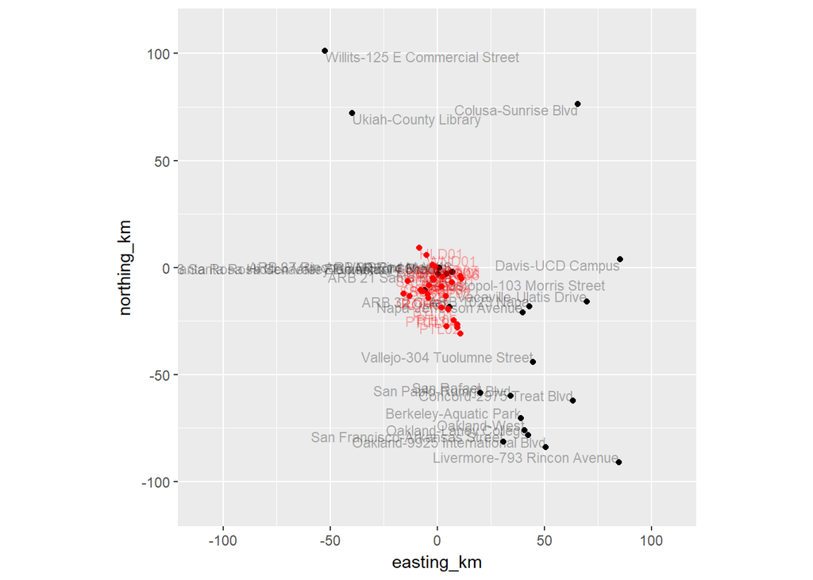

```r
farms<- farms %>%
  mutate(northing_km = 111.005*(lat-38.5), easting_km = 87.233*(long+122.75))

pm25 <- pm25 %>%
  mutate(northing_km = 111.005*(lat-38.5), easting_km = 87.233*(long+122.75))

ggplot(NULL, aes(easting_km, northing_km)) +
  geom_point(data = distinct(pm25,long,lat,.keep_all=TRUE)) +
  geom_text(data = distinct(pm25,long,lat,.keep_all=TRUE), color = "black", alpha = .3, aes(label = name), hjust = "inward", vjust = "inward", size = 3) +
  geom_point(data = farms, color = "red") +
  geom_text(data = farms, color = "red", alpha = .3, aes(label = Key), hjust = "inward", vjust = "inward", size = 3) +
  coord_fixed(xlim=c(-110,110),ylim=c(-110,110))
```

Q for Vanessa: any idea as to where the epicenter of burned industrial facilities was? That would have some significance for our choice of GPS location.

Currently using Larkfield-Wikiup for convenience (quarter-degree lat/long)

# graphs of sensor data

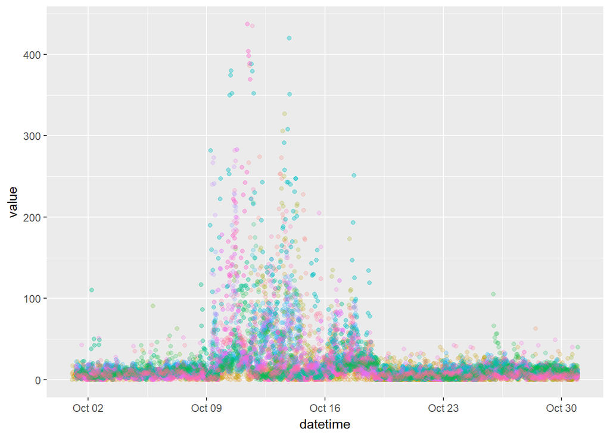

```r
pm25 %>%
  filter(datetime>as.Date("2017-10-1"), datetime<as.Date("2017-10-31")) %>%
  group_by(name) %>%
  ggplot(aes(datetime, value, color = name)) +
  geom_point(alpha = .2) +
  theme(legend.position = "none")
```

From this, I’ve arrived at the conclusion that Oct 8 - Oct 20 is a good span for the model run in order to capture the most serious part of the fire.

The only long term and short term sensors in close proximity were the Napa ones. Let’s compare:

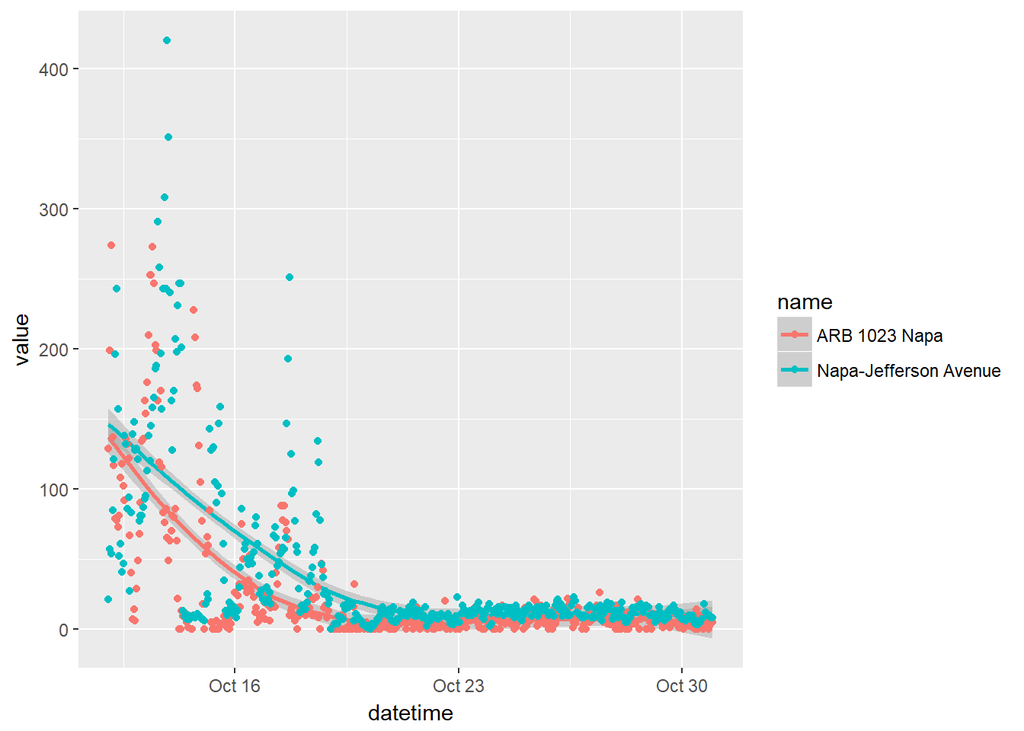

```r
#Set to start on Oct 12 because that's when the short term Napa sensor was placed
pm25 %>%
  filter(datetime>as.Date("2017-10-12"), datetime<as.Date("2017-10-31"), str_detect(name, "Nap")) %>%
  group_by(name) %>%
  ggplot(aes(datetime, value, color = name)) +
  geom_smooth() +
  geom_point()
```

Reasonably similar, especially given their slight geographic distance.

# stats on October sensor data

```r
pm25 %>%
  filter(datetime>as.Date("2017-10-1"), datetime<as.Date("2017-10-31")) %>%
  group_by(name) %>%
  summarize("n of measurements" = n(), mean = mean(value), min = min(value), Q1 = quantile(value, .25), median = median(value), Q3 = quantile(value, .75), max = max(value)) %>%
  arrange(desc(mean))
```

```
## # A tibble: 24 x 8
##    name                          `n o~  mean   min    Q1 medi~    Q3   max
##    <chr>                         <int> <dbl> <dbl> <dbl> <dbl> <dbl> <dbl>
##  1 Napa-Jefferson Avenue          1360  37.2  0     8.00 11.0   21.0   420
##  2 ARB 1023 Napa                   461  26.6  0     3.00  7.00  17.0   386
##  3 ARB 37 Rincon VMS 2nd Monitor   458  24.4  0     2.00  7.00  19.0   327
##  4 Vallejo-304 Tuolumne Street     709  21.8  1.00  7.00 11.0   18.0   435
##  5 Oakland-Laney College           708  20.6  0    10.0  15.0   21.0   135
##  6 San Pablo-Rumrill Blvd          667  19.8  1.00  7.00 11.0   17.0   241
##  7 Concord-2975 Treat Blvd         709  19.6  3.00  9.00 12.0   18.0   218
##  8 Oakland-West                    675  19.2  0     9.00 14.0   21.0   123
##  9 Ukiah-County Library            640  18.5  0     4.00  7.00  20.0   282
## 10 ARB 32 Cotati                   436  17.9  0     6.00 13.5   23.0   172
## # ... with 14 more rows
```

# sensor data coverage in October

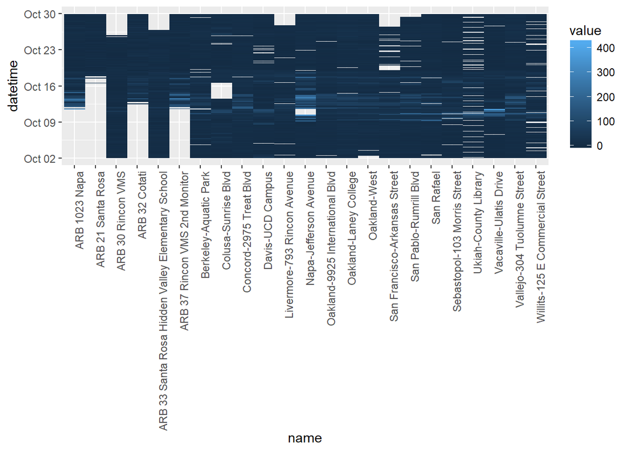

```r
#going to go with a range of 10/2-10/30 because sensors are running more or less dependably on that span

pm25 %>%
  filter(datetime>as.Date("2017-10-2"), datetime<as.Date("2017-10-30")) %>%
  group_by(name) %>%
  ggplot(aes(x = name, y = datetime)) +
  geom_raster(aes(fill = value)) +
  theme(axis.text.x = element_text(angle = 90, hjust = 1))
```

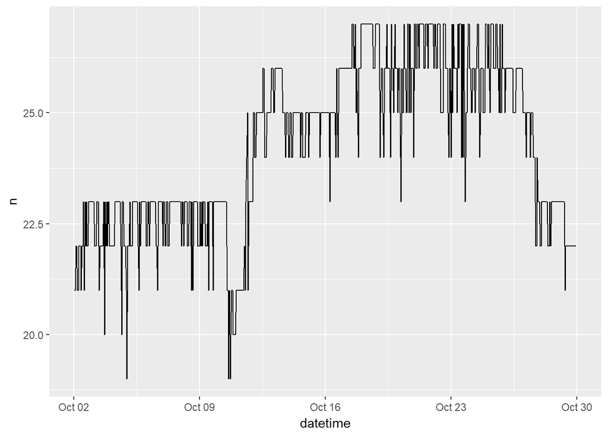

```r
pm25 %>%
  filter(datetime>as.Date("2017-10-2"), datetime<as.Date("2017-10-30")) %>%
  group_by(datetime) %>%
  summarise(n = n()) %>%
  ggplot(aes(datetime, n)) +
  geom_line()
```

# model function

```r
myIDW <- function(data = pm25, start_time = "2017-10-08", end_time = "2017-10-20",
                xmin = -110, xmax = 110, xinc = 1, ymin = -110, ymax = 110, yinc = 1,
                idp = 2, nmax = Inf, mdist = NULL) {

  stack <- list()

  j <- 0

  grid <- expand.grid(x = seq(xmin, xmax, xinc),
                      y = seq(ymin, ymax, yinc))

  coordinates(grid) <- ~x+y

  gridded(grid) <- TRUE

  for (i in seq.POSIXt(as.POSIXct(start_time), as.POSIXct(end_time), "hour")) {

    timepoint <- data %>%
      filter(datetime==i)

    coordinates(timepoint) <- ~easting_km+northing_km

    j <- j+1

    stack[[j]] <- as_tibble(idw(value~1, locations = timepoint, newdata = grid, idp = idp, nmax = nmax, maxdist = mdist))
    stack[[j]][4] <- as.POSIXct(start_time) + 3600*(j-1)
    colnames(stack[[j]]) <- c("raster_x", "raster_y", "value", "datetime")

    print(j)

  }

  return(stack)

}
```

# With all sensors

```r
krige <- myIDW(xmin = -30, xmax = 30, xinc = 1, ymin = -40, ymax = 20, yinc = 1, mdist = 55, idp = 1.5)

krige <- do.call(rbind, krige)

cumul <- krige %>%
  group_by(raster_x, raster_y) %>%
  summarize(s = sum(value))
```

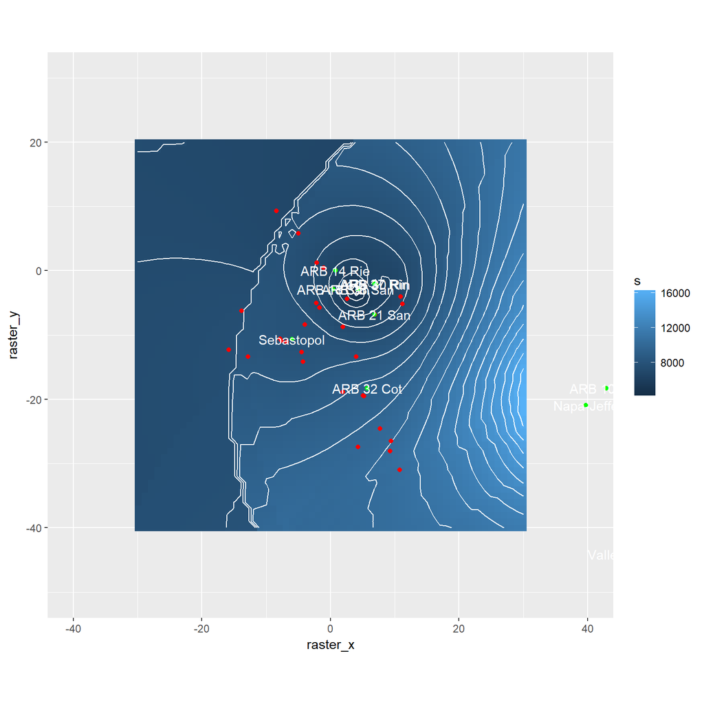

```r
cumul %>%
  ggplot(aes(raster_x, raster_y)) +
  geom_raster(aes(fill = s)) +
  geom_contour(aes(z = s), bins = 20, color = "white") +
  geom_point(data = farms, aes(farms$easting_km, farms$northing_km), color = "red") +
  geom_point(data = distinct(pm25,lat,long,.keep_all=TRUE), aes(easting_km, northing_km), color = "green") +
  geom_text(data = distinct(pm25,lat,long,.keep_all=TRUE), aes(easting_km, northing_km, label = key), color = "white") +
  coord_fixed(xlim=c(-40,40),ylim=c(-50,30))
```

```r
farms <- farms %>%
  mutate(raster_x = round(easting_km), raster_y = round(northing_km)) %>%
  left_join(rename(cumul, "allpm25" = s), c("raster_x", "raster_y"))
```

# Controlling for Napa interference:

## Including only local sensors

```r
krige <- myIDW(data = filter(pm25, abs(easting_km)<30, northing_km>-40, northing_km<20),
               xmin = -30, xmax = 30, xinc = 1, ymin = -40, ymax = 20, yinc = 1, mdist = 55, idp = 1.5)

krige <- do.call(rbind, krige)

cumul <- krige %>%
  group_by(raster_x, raster_y) %>%
  summarize(s = sum(value))
```

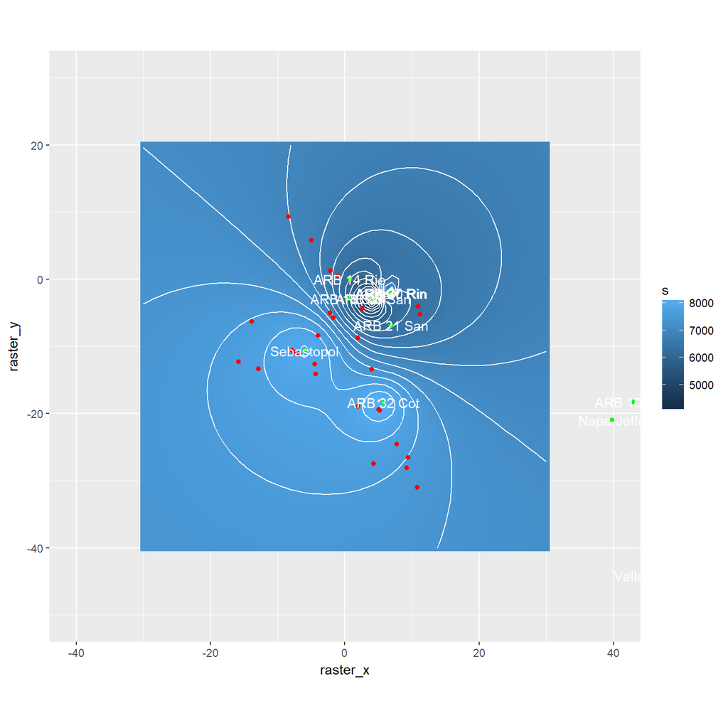

```r
cumul %>%
  ggplot(aes(raster_x, raster_y)) +
  geom_raster(aes(fill = s)) +
  geom_contour(aes(z = s), bins = 20, color = "white") +
  geom_point(data = farms, aes(farms$easting_km, farms$northing_km), color = "red") +
  geom_point(data = distinct(pm25,lat,long,.keep_all=TRUE), aes(easting_km, northing_km), color = "green") +
  geom_text(data = distinct(pm25,lat,long,.keep_all=TRUE), aes(easting_km, northing_km, label = key), color = "white") +
  coord_fixed(xlim=c(-40,40),ylim=c(-50,30))
```

```r
farms <- farms %>%
  mutate(raster_x = round(easting_km), raster_y = round(northing_km)) %>%
  left_join(rename(cumul, "localpm25" = s), c("raster_x", "raster_y"))
```

# Controlling for false negatives:

## Including only measurements above 5 ug/m3 (well below pre-fire background level)

This can sort of be thought of as a worst-case scenario. It might also cut down on the bias from the Napa sensor.

```r
krige <- myIDW(data = filter(pm25, value>5),
               xmin = -30, xmax = 30, xinc = 1, ymin = -40, ymax = 20, yinc = 1, mdist = 55, idp = 1.5)

krige <- do.call(rbind, krige)

cumul <- krige %>%
  group_by(raster_x, raster_y) %>%
  summarize(s = sum(value, na.rm = TRUE))
```

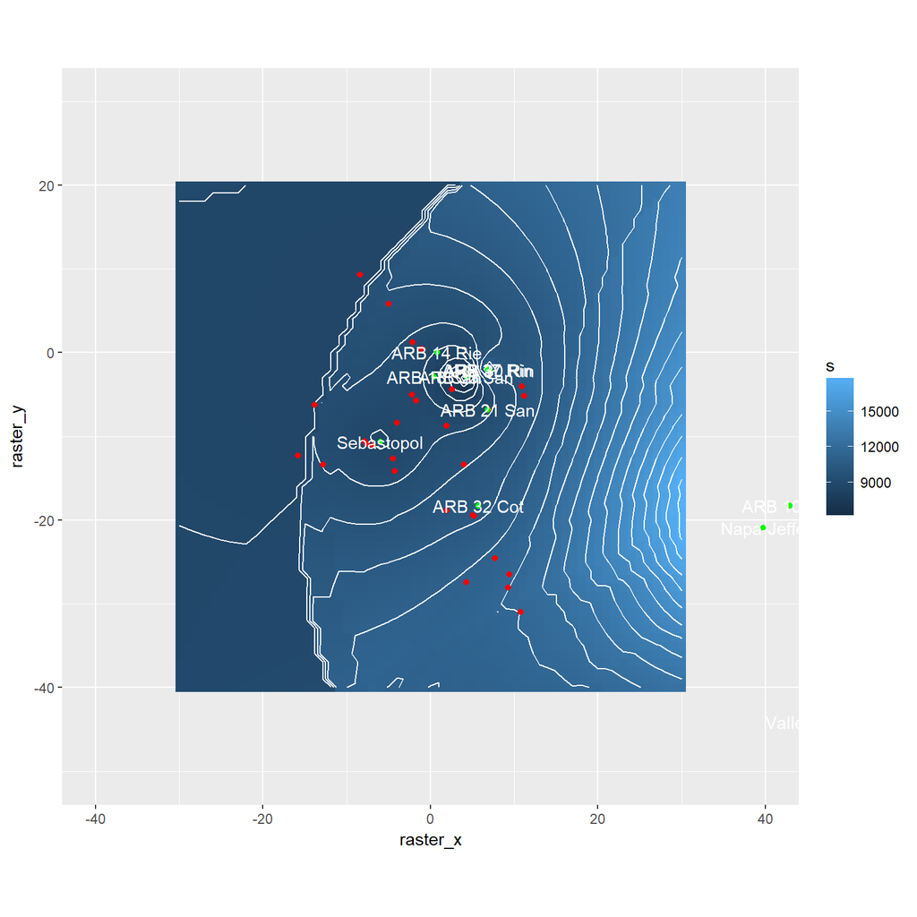

```r
cumul %>%
  ggplot(aes(raster_x, raster_y)) +
  geom_raster(aes(fill = s)) +
  geom_contour(aes(z = s), bins = 20, color = "white") +
  geom_point(data = farms, aes(farms$easting_km, farms$northing_km), color = "red") +
  geom_point(data = distinct(pm25,lat,long,.keep_all=TRUE), aes(easting_km, northing_km), color = "green") +
  geom_text(data = distinct(pm25,lat,long,.keep_all=TRUE), aes(easting_km, northing_km, label = key), color = "white") +
  coord_fixed(xlim=c(-40,40),ylim=c(-50,30))
```

```r
farms <- farms %>%
  mutate(raster_x = round(easting_km), raster_y = round(northing_km)) %>%
  left_join(rename(cumul, "falsenegspm25" = s), c("raster_x", "raster_y"))
```

# Finally, applying the false negative removal to the local data

```r
#had to use 0 for value to avoid model crashing (not totally sure why)
krige <- myIDW(data = filter(pm25, value>0, abs(easting_km)<30, northing_km>-40, northing_km<20),
               xmin = -30, xmax = 30, xinc = 1, ymin = -40, ymax = 20, yinc = 1, mdist = 55, idp = 1.5)

krige <- do.call(rbind, krige)

cumul <- krige %>%
  group_by(raster_x, raster_y) %>%
  summarize(s = sum(value, na.rm = TRUE))
```

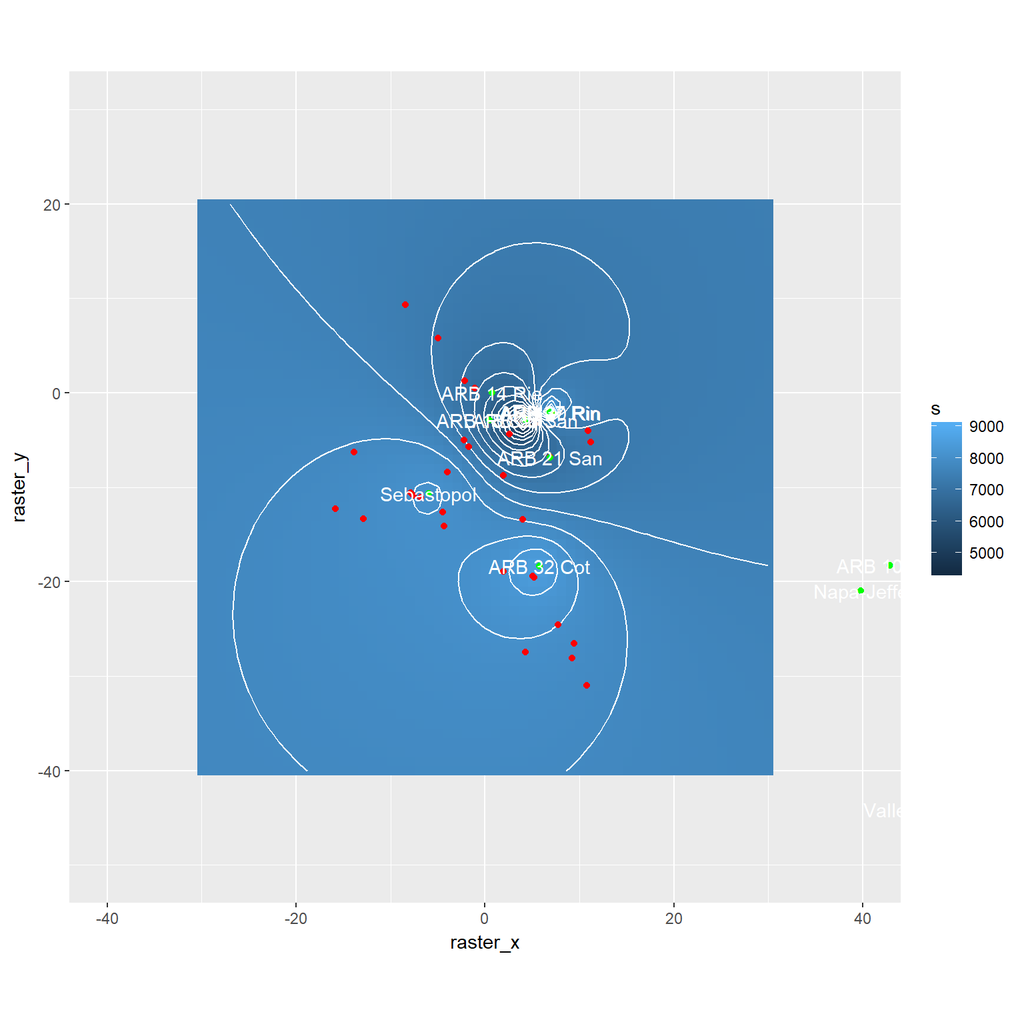

```r
cumul %>%
  ggplot(aes(raster_x, raster_y)) +
  geom_raster(aes(fill = s)) +
  geom_contour(aes(z = s), bins = 20, color = "white") +
  geom_point(data = farms, aes(farms$easting_km, farms$northing_km), color = "red") +
  geom_point(data = distinct(pm25,lat,long,.keep_all=TRUE), aes(easting_km, northing_km), color = "green") +
  geom_text(data = distinct(pm25,lat,long,.keep_all=TRUE), aes(easting_km, northing_km, label = key), color = "white") +
  coord_fixed(xlim=c(-40,40),ylim=c(-50,30))
```

```r
farms <- farms %>%
  mutate(raster_x = round(easting_km), raster_y = round(northing_km)) %>%
  left_join(rename(cumul, "localpm25above0" = s), c("raster_x", "raster_y"))
```

# Analyzing farm data

```r
farms <- farms %>%
  mutate(aq_norm = allpm25/max(allpm25),
         local_norm = localpm25/max(localpm25),
         pos_norm = falsenegspm25/max(falsenegspm25),
         both_norm = localpm25above0/max(localpm25above0)) %>%
  select(Key, address,
         HYSPLIT_raw = `Exposure (raw, final model, normalized)`,
         HYSPLIT_smooth = `Exposure (smoothed, final model, normalized)`,
         all_sensors = aq_norm,
         local_sensors = local_norm,
         wo_false_negs = pos_norm,
         local_wo_false_negs = both_norm)

kable(farms, digits = 5)
```

| Key | address | HYSPLIT_raw | HYSPLIT_smooth | all_sensors | local_sensors | wo_false_negs | local_wo_false_negs |
| --- | --- | --- | --- | --- | --- | --- | --- |
| OCC01 | 1935 Bohemian Hwy, Occidental, CA, 95465 | 0.24354 | 0.25621 | 0.71843 | 0.93518 | 0.74166 | 0.92979 |
| LKW01 | 478 Noonan Ranch Ln, Larkfield-Wikiup, CA, 95403 | 0.57196 | 0.66720 | 0.65713 | 0.78293 | 0.76605 | 0.81138 |
| SRO01 | 4993 Occidental Rd, Santa Rosa, CA, 95401 | 0.61255 | 0.56030 | 0.75298 | 0.94469 | 0.76289 | 0.93096 |
| PTL01 | 198 Ely Rd N, Petaluma, CA, 94954 | 0.49815 | 0.51998 | 0.94998 | 0.93541 | 0.97000 | 0.94555 |
| SRO02 | 301 Steele Ln, Santa Rosa, CA, 95403 | 1.00000 | 1.00000 | 0.50342 | 0.62944 | 0.62661 | 0.65273 |
| SRO03 | 1422 Forestview Dr, Santa Rosa, CA, 95401 | 0.44280 | 0.51123 | 0.69999 | 0.84974 | 0.76701 | 0.86021 |
| SBP01 | 459 Sequoia Ln, Sebastopol, CA, 95472 | 0.41328 | 0.41490 | 0.76118 | 0.96993 | 0.75328 | 0.94752 |
| ROH01 | 8657 Lancaster Dr, Rohnert Park, CA, 94928 | 0.49815 | 0.52388 | 0.87958 | 0.98901 | 0.89247 | 0.99048 |
| ROH02 | 8511 Liman Way, Rohnert Park, CA, 94928 | 0.49815 | 0.52388 | 0.87306 | 1.00000 | 0.88362 | 1.00000 |
| SRO04 | 885 Wildwood Trail, Santa Rosa, CA, 95409 | 0.80443 | 0.64134 | 0.67042 | 0.78434 | 0.86053 | 0.86196 |
| WND01 | 901 Adele Dr, Windsor, CA, 95492 | 0.57196 | 0.52572 | 0.74085 | 0.83548 | 0.83704 | 0.86188 |
| SRO05 | 6177 Sonoma Hwy, Santa Rosa, CA, 95409 | 0.74539 | 0.73075 | 0.68335 | 0.78676 | 0.85835 | 0.85736 |
| SRO06 | 1225 Fulton Rd, Santa Rosa, CA, 95401 | 0.44280 | 0.51573 | 0.71338 | 0.87022 | 0.76934 | 0.87633 |
| SBP02 | 6024 Fredricks Rd, Sebastopol, CA, 95472 | 0.41328 | 0.41200 | 0.77653 | 0.96029 | 0.78069 | 0.94493 |
| SRO07 | 651 Airport Blvd, Santa Rosa, CA, 95407 | 0.57196 | 0.61325 | 0.68103 | 0.80277 | 0.78498 | 0.83022 |
| SRO08 | 245 Mountain View Ave, Santa Rosa, CA, | 0.49815 | 0.55494 | 0.78091 | 0.89743 | 0.84024 | 0.91118 |
| SBP03 | 7450 Bodega Ave, Sebastopol, CA, 95472 | 0.41328 | 0.41967 | 0.75947 | 0.97473 | 0.74851 | 0.94984 |
| SBP04 | 1764 Cooper Rd, Sebastopol, CA, 95472 | 0.41328 | 0.42847 | 0.76975 | 0.96329 | 0.77007 | 0.94540 |
| PTL02 | 1001 McNear Ave, Petaluma, CA, 94952 | 0.39852 | 0.46403 | 1.00000 | 0.91173 | 1.00000 | 0.92607 |
| SBP05 | 11871 Bodega Hwy, Sebastopol, CA, 95472 | 0.24354 | 0.25721 | 0.78197 | 0.94627 | 0.79520 | 0.93614 |
| HLD01 | 12295 Old Redwood Hwy, Healdsburg, CA, 95448 | 0.40221 | 0.39688 | 0.65250 | 0.84936 | 0.73955 | 0.87343 |
| PTL03 | 4588 Bodega Ave, Petaluma, CA, 94952 | 0.33210 | 0.35214 | 0.93526 | 0.93664 | 0.95323 | 0.94460 |
| SBP06 | 7905 Valentine Ave, Sebastopol, CA, 95472 | 0.41328 | 0.40964 | 0.76118 | 0.96993 | 0.75328 | 0.94752 |
| SRO09 | 1717 Yulupa Ave, Santa Rosa, CA, 95405 | 0.73063 | 0.87510 | 0.65148 | 0.77472 | 0.79222 | 0.82202 |
| SRO10 | 1632 West Ave, Santa Rosa, CA, 95407 | 0.66790 | 0.72486 | 0.70421 | 0.83981 | 0.78470 | 0.85760 |
| PTL04 | 55 Shasta Ave, Petaluma, CA, 94952 | 0.49815 | 0.49885 | 0.97852 | 0.92231 | 0.99172 | 0.93456 |
| SBP07 | 4250 Bones Rd, Sebastopol, CA, 95472 | 0.27306 | 0.28881 | 0.71126 | 0.92584 | 0.73984 | 0.92231 |
| PTL05 | 1425 Sunrise Parkway, Petaluma, CA, | 0.49815 | 0.51787 | 0.97059 | 0.92482 | 0.98546 | 0.93677 |
| COT01 | 1075 Madrone Ave, Cotati, CA, 94931 | 0.33210 | 0.36806 | 0.85485 | 0.96976 | 0.87418 | 0.97118 |

## Correlations between HYSPLIT and AQ sensor data

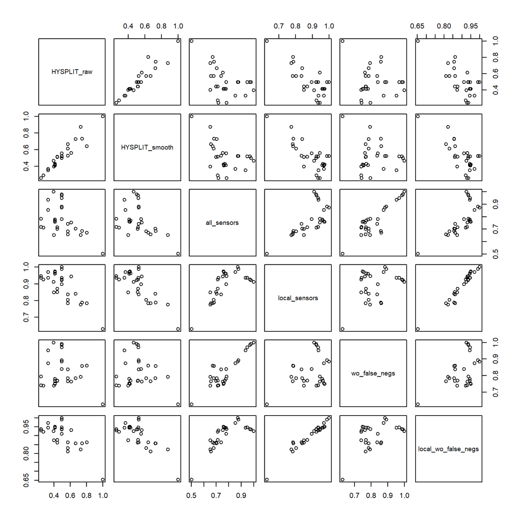

```r
pairs(farms[,3:8])
```

HYSPLIT and the air quality sensors just seem to be irreconciliably at odds.

# Perhaps this has all been too complicated. A simplistic approach to close with.

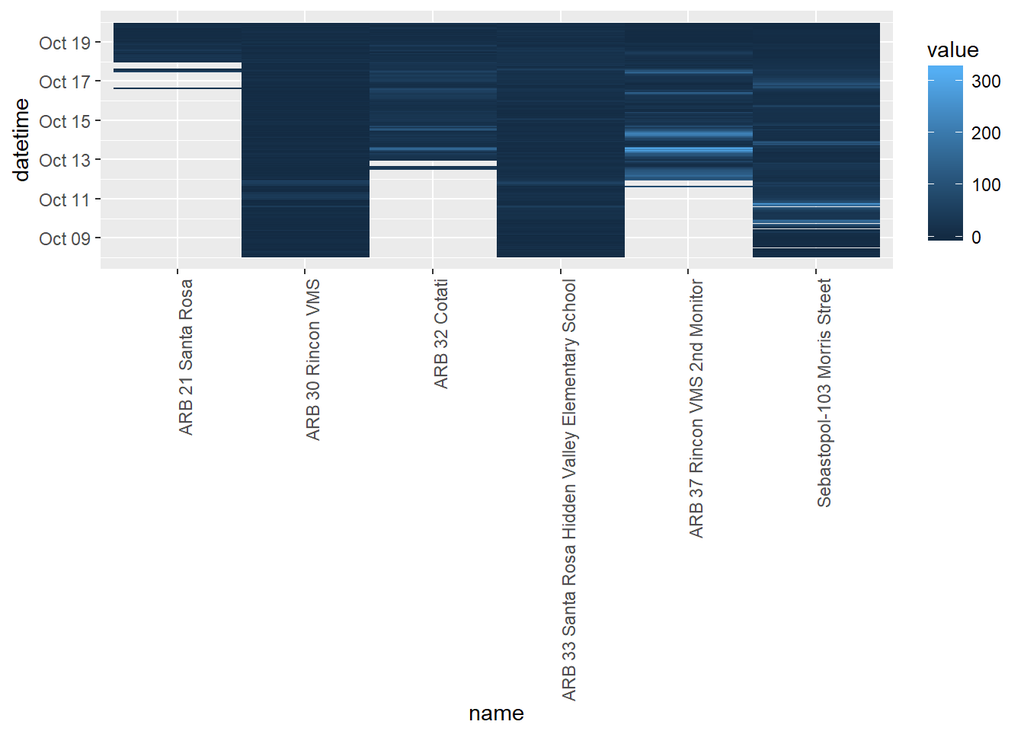

```r
pm25 %>%
  filter(datetime>as.Date("2017-10-8"), datetime<as.Date("2017-10-20"), abs(easting_km)<30, northing_km>-40, northing_km<20) %>%
  group_by(name) %>%
  ggplot(aes(x = name, y = datetime)) +
  geom_raster(aes(fill = value)) +
  theme(axis.text.x = element_text(angle = 90, hjust = 1))
```

Rincon Valley Middle School and the Sebastopol station recorded the most consistently high air quality measurements. If we have samples to spare, or if we just want to toss out the model, which might have been overkill to begin with, maybe choosing the closest farm to each of these locations would be a good idea.